# Nairobi Uber Visuals

Charles Hatfield & Marcel Reinmuth

2023-09-29

# 1 Introduction to the Data

This data is based on 2019 Uber mean road speed data measured by road segment, by hour, and by direction. I.e. The mean speed was 37 kph going north on Road Segment A between Intersection B and Intersection C. For our purposes we subset the data to the morning rush hour between 6-9 am. The data was further split into the semester and holiday period with public holidays, mid-semester school breaks, and national secondary school exam period removed. The 2019 Nairobi public school system calendar was used to set the semester and holiday breakpoints. The school system is on a trimester system interspersed with mid-semester breaks and three holiday periods. The national exam period follows the 3rd semester prior to the 3rd holiday period.

For our data exploration we tried various approaches including aggregating the speed data across the separate semester and holiday periods as well as across the morning and afternoon. For the following visuals and t-test we settled on simply subsetting for the morning rush hour period 6-9am and splitting the data by date into either a semester or holiday category The data was otherwise kept disaggregated. The result is that we have 4,377,270 road segment speed measurements for the semester period and 2,030,756 in the holiday period. Each observation in the data frames for both represents one road segment at one hour on one day in one direction. Therefore each segment could appear up to 3 times per day one for each hour period in one direction and another 3 times in the other direction.

**Our question is whether or not this is the appropriate way to handle time series data with a high N. Hopefully you all could provide inside into a more sensitive or appropriate way to handle this data.**

*Included in this rmd are the plots and t test for illustrative purposes, but the core of the analysis is in the data prep script.*

## 1.1 Libraries

```r
library(sf)
library(tidyverse)
library(lubridate)
library(stats)
```

## 1.2 Loading Data

```r
morn_df <- readRDS("data/morn_df.rds")
semhol_dfs <-load("data/semhol_dfs.RData")
morn_roads <- readRDS("data/morn_roads.rds")
```

## 1.3 Daily Time Series

## 1.4 Preparing plotting data

```r
# Daily Mean
week_df <- morn_df |> filter(week == 1 & holiday == 0) |>
  group_by(date) |>
  summarise(mean_speed_kph = mean(speed_kph_mean, na.rm = TRUE))

# Weekend days subset
weekend_df <- morn_df |> filter(week == 0) |>
  group_by(date) |>
  summarise(mean_speed_kph = mean(speed_kph_mean, na.rm = TRUE)) |>
  mutate(dayofweek = wday(date, label = TRUE))

# Public Holidays subset
hols_df <- morn_df |> filter(holiday == 1) |>
  group_by(date) |>
  summarise(mean_speed_kph = mean(speed_kph_mean, na.rm = TRUE)) |>
  mutate(dayofweek = wday(date, label = TRUE))

# Combining holidays and weekends together for proper factoring and legend
weekend_df$Day_Type <- ifelse(weekend_df$dayofweek == "Sat", "Saturday", "Sunday")
hols_df$Day_Type <- "Public Holiday"

# Plotting df for weekend and holiday
all_df <- rbind(weekend_df, hols_df)
```

```r
# Restructuring semester and holiday data for geom ribbons
# Ribbon helper function
expand_dates <- function(df){
  data.frame(date = seq(df$min_date, df$max_date, by="day"),
             mean_kph = df$mean_kph,
             se_kph = df$se_kph
             )
}


sem1_exp <- expand_dates(sem1)
hol1_exp <- expand_dates(hol1)
sem2_exp <- expand_dates(sem2)
hol2_exp <- expand_dates(hol2)
sem3_exp <- expand_dates(sem3)
hol3_exp <- expand_dates(hol3)
```

## 1.5 Daily Mean Speed Plot

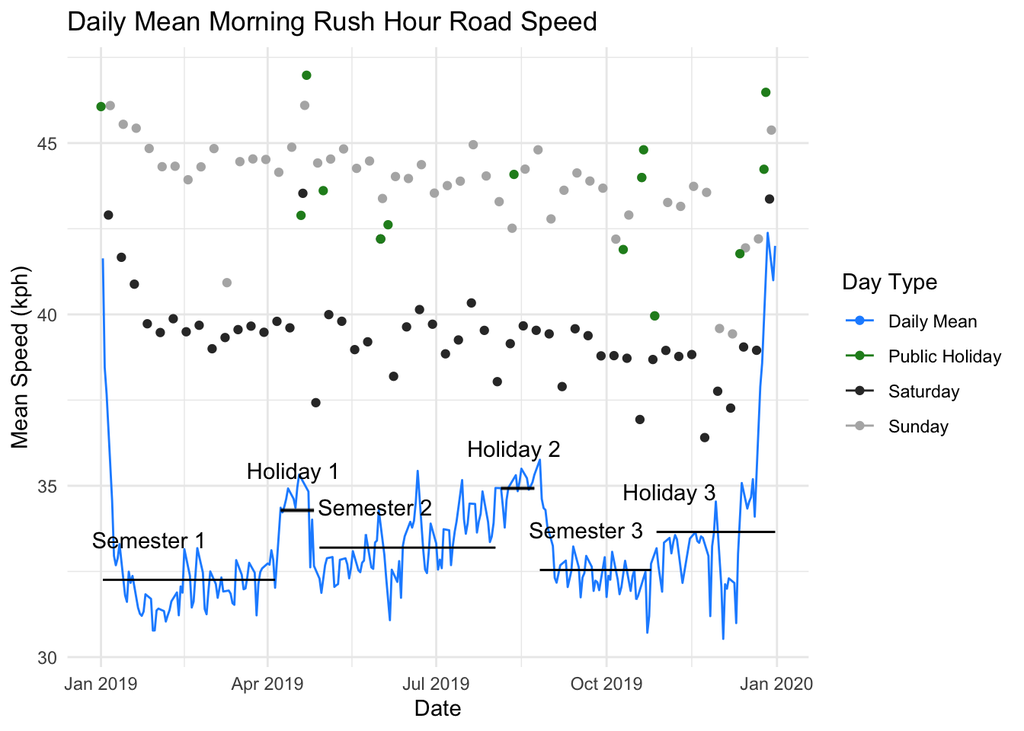

Daily mean road speeds during the morning rush hour 6-9am with semester and holiday means as bars. Standard errors are included but effectively have shrank to near 0. Semester and holiday means and standard errors were calculated on all road speeds for all segments between the 6-9 am window for each respective period.

## 1.6 Daily Mean Morning Rush Hour Speed by Road Type Plot

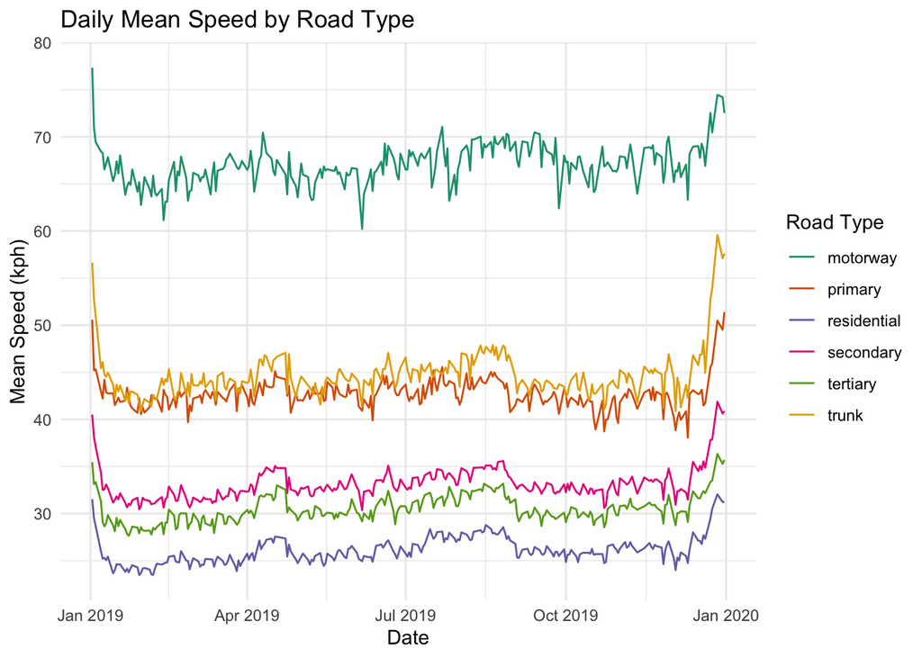

Daily mean road speeds split by OSM highway type.

# 2 Mean Road Speed Semester v Holiday T-Test

## 2.1 T-Test Full Sample

```r
t_test <- t.test(semester1$speed_kph_mean, holiday1$speed_kph_mean)

print(t_test)
```

```
##
##  Welch Two Sample t-test
##
## data:  semester1$speed_kph_mean and holiday1$speed_kph_mean
## t = -115.18, df = 3965540, p-value < 2.2e-16
## alternative hypothesis: true difference in means is not equal to 0
## 95 percent confidence interval:
##  -1.551912 -1.499981
## sample estimates:
## mean of x mean of y
##  34.73004  36.25599
```

```r
f_test <- var.test(semester1$speed_kph_mean, holiday1$speed_kph_mean)
print(f_test)
```

```
##
##  F test to compare two variances
##
## data:  semester1$speed_kph_mean and holiday1$speed_kph_mean
## F = 1.0048, num df = 4377269, denom df = 2030755, p-value = 7.092e-05
## alternative hypothesis: true ratio of variances is not equal to 1
## 95 percent confidence interval:
##  1.002830 1.006739
## sample estimates:
## ratio of variances
##           1.004784
```

## 2.2 T-Test Minus Holidays and Weekends

```r
t_test2 <- t.test(semester2$speed_kph_mean, holiday2$speed_kph_mean)

print(t_test2)
```

```
##
##  Welch Two Sample t-test
##
## data:  semester2$speed_kph_mean and holiday2$speed_kph_mean
## t = -68.176, df = 3092313, p-value < 2.2e-16
## alternative hypothesis: true difference in means is not equal to 0
## 95 percent confidence interval:
##  -0.9953901 -0.9397575
## sample estimates:
## mean of x mean of y
##  34.32499  35.29256
```

```r
f_test2 <- var.test(semester2$speed_kph_mean, holiday2$speed_kph_mean)
print(f_test2)
```

```
##
##  F test to compare two variances
##
## data:  semester2$speed_kph_mean and holiday2$speed_kph_mean
## F = 1.0222, num df = 4109045, denom df = 1656830, p-value < 2.2e-16
## alternative hypothesis: true ratio of variances is not equal to 1
## 95 percent confidence interval:
##  1.020039 1.024441
## sample estimates:
## ratio of variances
##           1.022239
```

## 2.3 T-Test Aggregated by Day

```r
t_test3 <- t.test(semester3$speed_kph_mean, holiday3$speed_kph_mean)

print(t_test3)
```

```
##
##  Welch Two Sample t-test
##
## data:  semester3$speed_kph_mean and holiday3$speed_kph_mean
## t = -2.0984, df = 161.55, p-value = 0.03743
## alternative hypothesis: true difference in means is not equal to 0
## 95 percent confidence interval:
##  -2.12285201 -0.06442326
## sample estimates:
## mean of x mean of y
##  34.92523  36.01887
```

```r
f_test3 <- var.test(semester3$speed_kph_mean, holiday3$speed_kph_mean)
print(f_test3)
```

```
##
##  F test to compare two variances
##
## data:  semester3$speed_kph_mean and holiday3$speed_kph_mean
## F = 1.1028, num df = 231, denom df = 86, p-value = 0.6064
## alternative hypothesis: true ratio of variances is not equal to 1
## 95 percent confidence interval:
##  0.7645457 1.5457070
## sample estimates:
## ratio of variances
##           1.102772
```